# Sae S2.04

The Nutri-Score is a food product rating system, assigning a grade ranging from “A” to “E”. It is calculated using an algorithm based on points allocated according to the quantity of energy, simple sugars, saturated fatty acids, sodium, fibers, and proteins.

Our study will focus on the relationship between Nutri-Score and pizzas, pies, and quiches in the United States. Our dataset contains approximately 3000 products.

# 1 - Distribution table of Nutri-Score for pizzas, pies, and quiches:

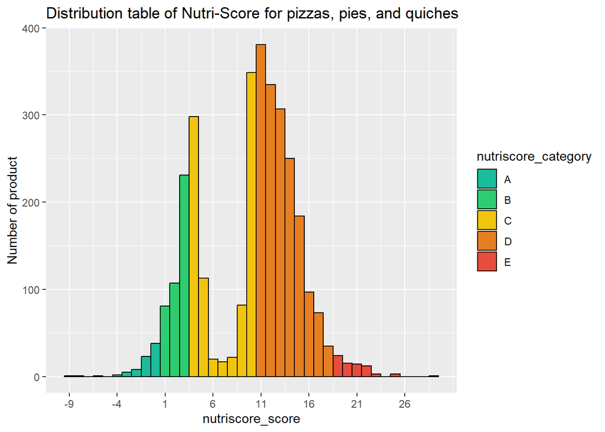

this separation is due to a negative peek in the middle of the C category, indeed most of the product in the C category have a nutriscore close to a B nutriscore or a D one

# 2 - Percentage of organic products for each Nutri-Score category

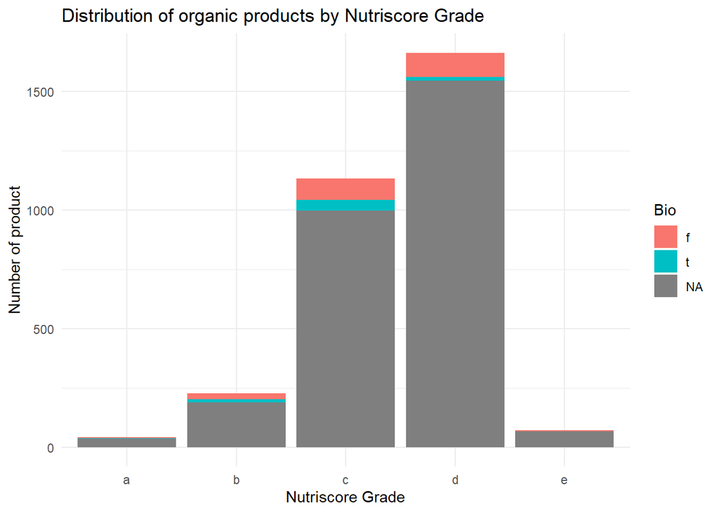

```
## Number of Organic product : 77
##  Total number of products 3133
##  percentage of organic product on this dataset :  2.457708 %
```

This second histogram show the percentage of organic product (in blue) compared to the rest of the product in the same nutriscore category we can deduce from the data that we have here that being an organic product or not doesn’t necessarily means a better nutriscore grade and that, in general, pizza quiche and pie aren’t really the type of product to be organic, in fact , when we are counting the number of organic product compared to the total product we observe that the number of organic prodcut is insignificant compared to the rest But we have to be carefull with those data since they might not be enough to make a clear conclusion as there are a lot of product where the field is not filled in

# 3 - Saturated fat content in pizzas, pies, and quiches according to the Nutriscore.

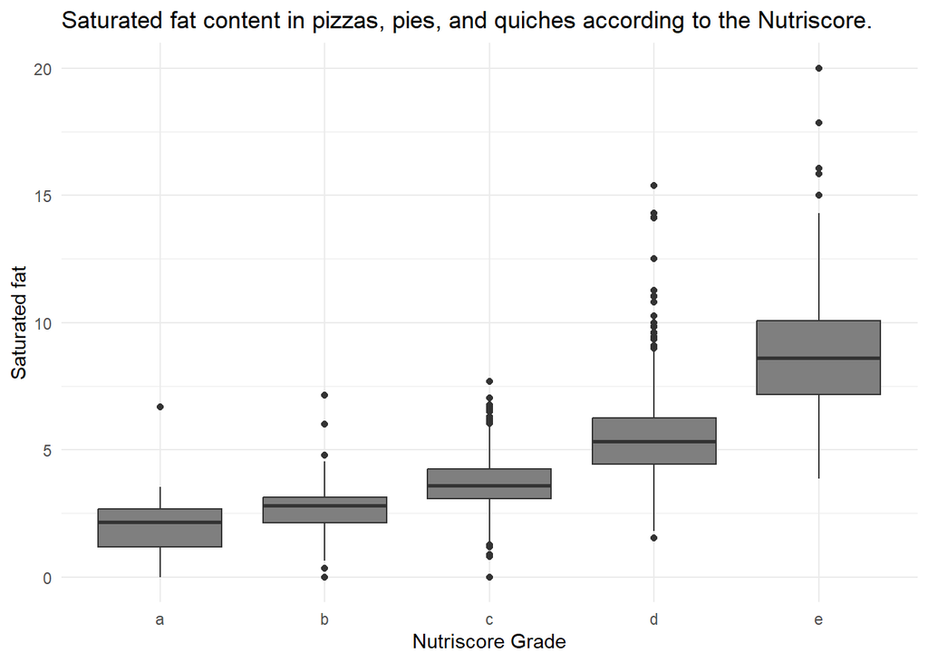

This boxplot shows the distribution of saturated fat content for each nutriscore category.

We can observe a link between saturated fat content and the nutriscore.

The higher the saturated fat content, the lower the nutriscores.

Saturated fat content is therefore an important factor in calculating the score.